# Section 3

###### V. Hunter Adams

```python
from IPython.display import Latex
import matplotlib.pyplot as plt
%matplotlib inline
import numpy
from matplotlib import animation, rc
from IPython.core.display import HTML
from IPython.display import HTML
from ipywidgets import *
from scipy.integrate import odeint
from IPython.display import Image
```

## Gravitational and Electromagnetic Forces

Both gravitational and electromagnetic forces obey an inverse square law (the strength of the force decreases with the square of the distance). However, the scales of these laws are very different. Let's get a sense for orders of magnitude. We'll calculate the strength of the gravitational force between the Earth and the Moon, and the strength of the electromagnetic force between a proton and electron.

#### Gravity: Earth and Moon

Gravitational force is given by:

\begin{align} F_G &= \frac{GM_EM_M}{R^2}\\ \end{align}

where

\begin{align} G &= 6.67 \times 10^{-11} \frac{m^{3}}{kg\cdot sec^2}\\ M_E &= 5.97 \times 10^{24} kg\\ M_M &= 7.35 \times 10^{22 kg}\\ R_{E\rightarrow M} &= 384,400,000 m \end{align}

So, substituting:

\begin{align} F_G &= \frac{\left(6.67 \times 10^{-11}\right) \left(5.97 \times 10^{24}\right) \left(7.35 \times 10^{22}\right)}{\left(3.844\times 10^{8}\right)^2}\\ &= 1.98 \times 10^{20} N \end{align}

#### Electromagnetic: Proton and Electron

Electromagnetic force is given by:

\begin{align} F_{EM} &= \frac{kq_eq_p}{R^2}\\ \end{align}

where:

\begin{align} q_e &= -1.6\times 10^{-19}C\\ q_p &= 1.6 \times 10^{-19}C\\ R&= 0.1 \times 10^{-9}m\\ k &= 9\times 10^{9}\frac{kg\cdot m^3}{C^2\cdot sec^2} \end{align}

Substituting:

\begin{align} F_{EM} &= \frac{\left(9\times 10^{9}\right)\left(-1.6\times 10^{-19}\right)\left(1.6 \times 10^{-19}\right)}{\left(0.1 \times 10^{-9}\right)^2}\\ &= 2.304 \times 10^{-8}N \end{align}

But this is an apples and oranges comparison. If we really want to compare relative strenghts, we should calculate the forces on equivalent scales. Let's calculate the gravitational force between a proton and an electron:

\begin{align} F_G &= \frac{GM_eM_p}{R^2}\\ \end{align}

where

\begin{align} G &= 6.67 \times 10^{-11} \frac{m^{3}}{kg\cdot sec^2}\\ M_e &= 9.12 \times 10^{-31} kg\\ M_p &= 1.67 \times 10^{-27} kg\\ R_{e\rightarrow p} &= 0.1 \times 10^{-9} m \end{align}

Substituting:

\begin{align} F_G &= \frac{\left(6.67 \times 10^{-11}\right) \left(9.12 \times 10^{-31}\right) \left(1.67 \times 10^{-27}\right)}{\left(0.1\times 10^{-9}\right)^2}\\ &= 1.02\times 10^{-47} N \end{align}

Gravity is WAY weaker than the electromagnetic force. In fact, it's the weakest of the fundamental forces. The reason it's so important is because it operates over such long distances.

## Wien's Law

#### Cosmic Microwave Background

*Question*: Does anybody know what the most perfect example of a blackbody ever observed in nature is?

*Answer*: The Cosmic Microwave Background Radiation.

Seriously, do a Wikipedia search for Cosmic Microwave Background and look at the data from the COBE spacecraft plotted on top of the ideal blackbody curve. It's insane.

*Question*: What is the CMB?

*Answer*: When the universe was very young, it was extremely hot. The protons, neutrons, and electrons existed as a plasma (they were too energetic to join together into nuclei and atoms). The thing about plasma is that photons (bits of light) interact with it. This means that light traveling through a plasma can't really escape, it's always getting bounced around in random directions. When the universe cooled enough for protons and electrons and neutrons to come together, however (around 3000K), the photons no longer interacted with them. They could escape. These are the photons that now make up the cosmic microwave background. (Small asymmetries are from quantum fluctuations getting inflated to the size of the universe, how insane is that?).

The CMB's spectrum peaks in the microwave region ($\lambda = 1.063mm$). What is its temperature?

\begin{align} \lambda_{max} = \frac{2898 \mu m \cdot T}{T} \end{align}

We can solve for $T$:

\begin{align} T &= \frac{2898}{\lambda_{max}} \end{align}

From the COBE data, we know $\lambda_{max} = 1.063mm$.

Substituting:

That's pretty cold. Remember that 0 is absolute 0.

#### Lava

Lava looks reddish. The peak of its emission spectrum is at about 1.97 $\mu m$ (in the infrared). It emits into the red end of the visible spectrum, but less intensely. What is its temperature, assuming that it is a blackbody emitter?

\begin{align} \lambda_{max} &= \frac{2898 \mu m \cdot T}{T} \end{align}

Solve for $T$:

\begin{align} T &= \frac{2898}{\lambda_{max}} \end{align}

Solve:

\begin{align} T &= \frac{2898}{1.97}\\ &= 1471K\\ &= 1197 C \end{align}

## Stefan-Boltzmann

The energy emitted per unit time per unit area is proportional to the fourth power of temperature:

\begin{align} F &= \sigma T^4 \end{align}

Consider the Sun, with temperature $T_s$ and radius $R_s$. Supposer I have another star that has the same temperature but twice the radius. Which star emits more energy, and by how much?

Remember that the equation above is energy per unit time per unit area. So, to get energy per unit time, we need to multiply by the area:

\begin{align} A = \pi R^2 \end{align}

So the energy per unit time for the Sun is:

\begin{align} E_s &= \pi R_s^2 \sigma T_s^4 \end{align}

How about for the other star? Well, for the other star $T=T_s$, and $R=2R_s$. So the energy per unit time is:

\begin{align} E_o &= \pi (2R_s)^2\sigma T_s^4\\ &= 4 \pi R_s^2 \sigma T_s^4 \end{align}

What's the ratio of these energies?

\begin{align} \frac{E_o}{E_s} &= \frac{4 \pi R_s^2 \sigma T_s^4}{\pi R_s^2 \sigma T_s^4}\\ &= 4 \end{align}

The other star emits *4 times as much energy as the Sun, per unit time*. Let's change it up, suppose the other star were half the size of the Sun, but twice as hot:

\begin{align} E_o &= \pi \left(\frac{1}{2}R_s\right)^2 \sigma (2T_s)^4\\ &= \pi \frac{1}{4} R_s^2 \sigma 16 T_s^4\\ &= 4 \pi R_s^2 \sigma T_s^4 \end{align}

Giving the ratio:

\begin{align} \frac{E_o}{E_s} &= \frac{4 \pi R_s^2 \sigma T_s^4}{\pi R_s^2 \sigma T_s^4}\\ &= 4 \end{align}

The other star emits four times the energy per unit time.

## Absorption and Emission Spectra

The Sun can be modeled as a blackbody. When its light travels through the cooler nebula (composed of Hydrogen and Helium, among other things), the light at the appropriate energies kicks an electron into a higher energy level. This means that the absorption spectrum will look like a blackbody spectrum, with holes at the wavelengths associated with those energies. When the electrons fall back into a lower energy level, they emit a photon in a random direction. Thus, the emission spectrum looks essentially like zero except for the spikes at the appropriate wavelenghts for hydrogen and helium.

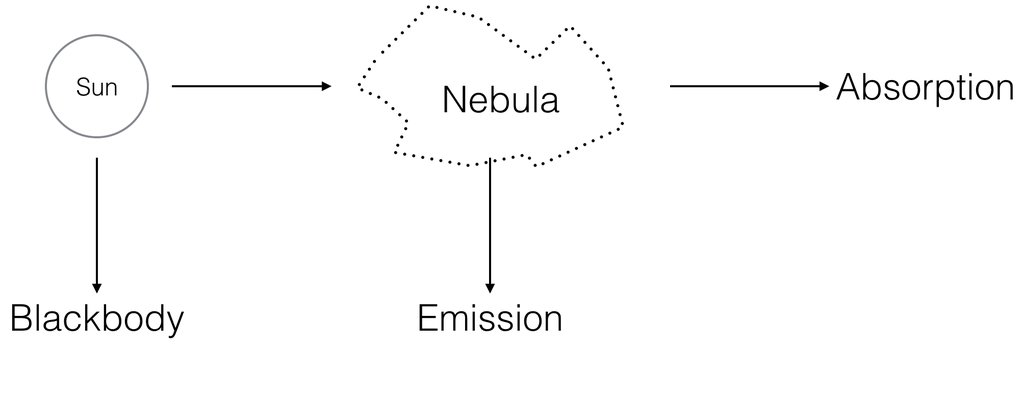

```python
PATH = "/Users/hunteradams/Documents/PhD Semester 5/Sections/"
Image(filename = PATH + "black.png", width=600, height=600)
```

*An aside if time permits. Photoelectric effect shows particle-like property of electrons (matter), does anyone know the experiment that shows the wave-like properties? (Double-slit)*

## Telescopes

The relevant quantities:

\begin{align} \alpha &= \frac{s}{r} \end{align}

Where $\alpha$ is the angular separation between to point objects, $s$ is the distance separating those objects, and $r$ is the distance from the observer to those objects.

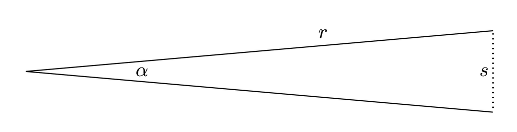

```python
Image(filename = PATH + "alpha.png", width=600, height=600)
```

The diffraction limit, $\theta$, is given by:

\begin{align} \theta &= \frac{\lambda}{D} \end{align}

Sensitivity is proportional to the amount of photons that you collect, which is proportional to the area of the telescope aperature.

\begin{align} sensitivity \propto \pi \left(\frac{D}{2}\right)^2 \end{align}

*Question*: If you want to make a microwave telescope ($\lambda = 1.063\times 10^{-3}m$) with the same resolution as the human eye ($\theta = 60''$). How big of an aperature do you need?

\begin{align} \theta &= \frac{\lambda}{D} \end{align}

Solve for $D$:

\begin{align} D &= \frac{\lambda}{\theta} \end{align}

Convert $\theta$ to radians:

\begin{align} \theta &= \frac{60''}{1}\frac{1'}{60''}\frac{1deg}{60'}\frac{2\pi rad}{360deg}\\ &= 2.9 \times 10^{-4} rad \end{align}

And solve:

You'd want a telescope with a diameter of about 3.66m.

## Doppler

The Doppler effect is a consequence of the fact that the speed of light is constant. Light is a wave - a series of peaks and troughs. If an object emitting light is stationary relative to me, the observer, then the distance between the peaks and troughs is the wavelength of the emitted light. However, if the object is moving towards me, then the object moves a little bit in between peaks. It moves in the direction that the light is traveling, so the peaks are closer together (shorter wavelength - blueshifted). If it is moving away, the peaks are farther apart (longer wavelength - redshifted).

The amount of shifting is given by:

\begin{align} \frac{\Delta \lambda}{\lambda} &= \frac{v}{c} \end{align}

where $\Delta \lambda$ is the amount the wavelength changes, $v$ is the velocity of the object, and $c$ is the speed of light ($3\times 10^8 m/s$). Wavelength is related to frequency according to:

\begin{align} f &= \frac{c}{\lambda} \end{align}